# Exercise 10

Author

Sarah Lötscher

Published

November 20, 2022

```r
knitr::opts_chunk$set(echo = TRUE)
```

## Preprocessing and Clustering of a PBMC single cell RNA-seq data

The single cell dataset consists of peripheral blood mononuclear cells. These cells comprise different cell types. For each cell the ground truth is provided in terms of the assigned cell type that was derived using additional data. A cell has “unassigned” as cell type if it could not be reliably assigned to a cell type.

1. Modify the quality-based cell filtering to remove the low quality cells that could not be assigned. Try with different thresholds
2. Try different clustering methods and parameters such that different cell types are in separate clusters.

Below is an example workflow inspired by http://bioconductor.org/books/release/OSCA/

```r
library(stats)
suppressPackageStartupMessages(library(scran))
suppressPackageStartupMessages(library(scater))
suppressPackageStartupMessages(library(BiocParallel))
suppressPackageStartupMessages(library(ggplot2))
suppressPackageStartupMessages(library(HDF5Array))
suppressPackageStartupMessages(library(hdf5r))
suppressPackageStartupMessages(library(pheatmap))
BPPARAM = BiocParallel::MulticoreParam(workers=2)
BPPARAM = BiocParallel::SerialParam()
```

#Default Kmeans clustering with modifyed quality-based cell filtering

## Load the data

```r
startTime = proc.time()
```

```r
sce = readRDS("pbmc-sce.RDS")
sce
```

```
class: SingleCellExperiment
dim: 36601 10194
metadata(1): Samples
assays(1): counts
rownames(36601): ENSG00000243485 ENSG00000237613 ... ENSG00000278817
  ENSG00000277196
rowData names(3): ID Symbol Type
colnames: NULL
colData names(3): Sample Barcode cellType
reducedDimNames(0):
mainExpName: NULL
altExpNames(0):
```

Optionally subsample 2000 cells to reduce runtime

```r
set.seed(38)
sce = sce[ , sample(1:ncol(sce), size = 2000, replace = FALSE)]
```

The cell type abundandances are

```r
cd = as.data.frame(colData(sce))
ggplot(cd, aes(x=cellType)) + geom_bar() +
   scale_fill_manual() + theme(axis.text.x = element_text(angle = 45, vjust = 1, hjust=1))
```

[output not shown]

## Modify the quality-based cell filtering to remove the low quality cells that could not be assigned

Compute quality scores

```r
isMito <- grepl("^mt-", rowData(sce)$Symbol, ignore.case=TRUE)

sce <- addPerCellQC(sce, subsets=list(Mito=isMito), percent_top=100,
                    detection_limit=0, BPPARAM=BPPARAM)
```

Filter by quality

```r
qc.lib <- isOutlier(sce$sum, log=TRUE, type="lower",nmads = 1.8)
qc.nexprs <- isOutlier(sce$detected, log=TRUE, type="lower",nmads = 1.8)
qc.mito <- isOutlier(sce$subsets_Mito_percent, type="higher",nmads = 1.8)
qc.top <- isOutlier(sce$percent.top_100, type="higher",nmads = 1.8)

discard <- qc.lib | qc.nexprs | qc.mito | qc.top

DataFrame(LibSize=sum(qc.lib), NExprs=sum(qc.nexprs),
          MitoProp=sum(qc.mito),
          TopProp=sum(qc.top), Total=sum(discard))
```

```
DataFrame with 1 row and 5 columns
    LibSize    NExprs  MitoProp   TopProp     Total
  <integer> <integer> <integer> <integer> <integer>
1       180       136       230        21       286
```

```r
sce$discard = discard

sceFilt = sce[ , !sce$discard]
minCellsExpressed = 5
isExpressed <- Matrix::rowSums(counts(sceFilt) >= 1) >= minCellsExpressed
sceFilt = sceFilt[isExpressed, ]
```

Normalize

```r
sceFilt = logNormCounts(sceFilt)
```

Compute reduced dimension representation

```r
set.seed(38)
dec <- modelGeneVarByPoisson(sceFilt, BPPARAM=BPPARAM)
topGenes <- getTopHVGs(dec, n = 2000)
sceFilt <- runPCA(sceFilt, subset_row=topGenes, BPPARAM=BPPARAM)
sceFilt <- runUMAP(sceFilt, dimred="PCA", BPPARAM=BPPARAM)
```

Cluster

```r
set.seed(100)
clust.kmeans <- kmeans(reducedDim(sceFilt, "PCA"), centers=10)
table(clust.kmeans$cluster)
```

```
  1   2   3   4   5   6   7   8   9  10
159 208  84 227 232 196 103 218 168 119
```

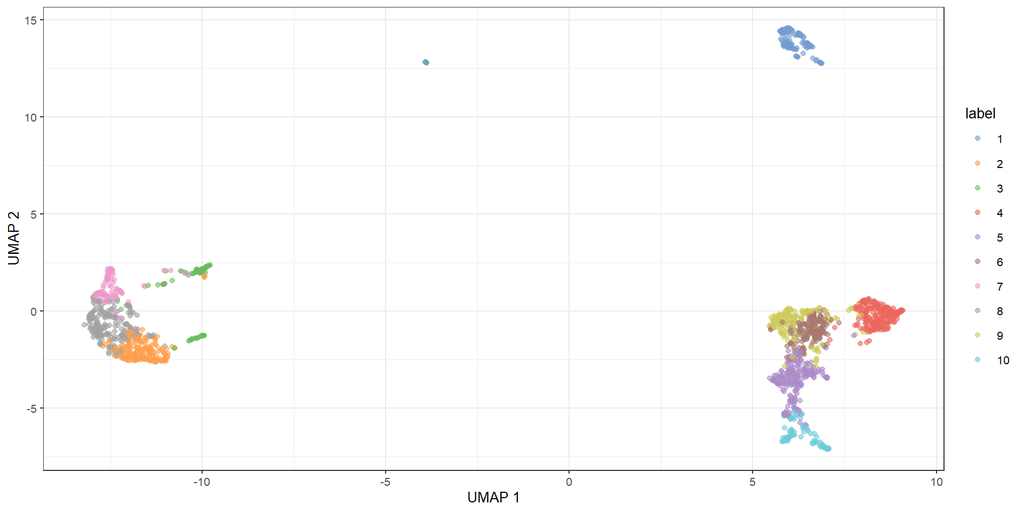

```r
colLabels(sceFilt) <- factor(clust.kmeans$cluster)
plotReducedDim(sceFilt, "UMAP", colour_by="label")
```

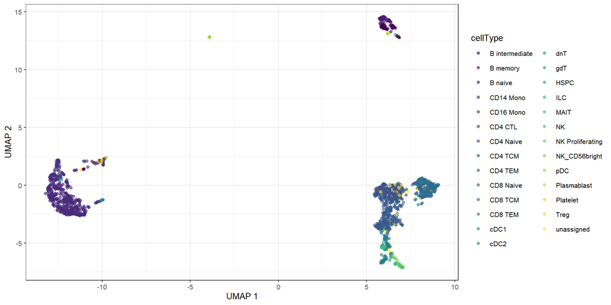

```r
plotReducedDim(sceFilt, "UMAP", colour_by="cellType")
```

Agreement of clusters with cell types

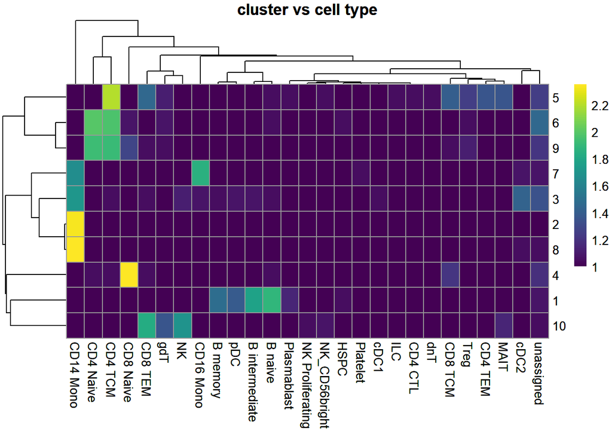

```r
tab <- table(sceFilt$label, sceFilt$cellType)
phm <- pheatmap(log10(tab+10), main="cluster vs cell type",
    color=viridis::viridis(100), silent=FALSE)
phm
```

## Result

Sensitivity and specificity of low quality cell detection

```r
mean(sce$discard[sce$cellType == "unassigned"])
```

```
[1] 0.5864662
```

```r
mean(!sce$discard[sce$cellType != "unassigned"])
```

```
[1] 0.8885913
```

Agreement of clustering and cell type

```r
mclust::adjustedRandIndex(sceFilt$label,sceFilt$cellType)
```

```
[1] 0.4629327
```

Runtime in seconds

```r
paste(signif((proc.time() - startTime)[ "elapsed"], digits=4), "s")
```

```
[1] "21.64 s"
```